# An overview of Propensity Score Matching

Xindi Ni, Xin Zeng

Apr.7 2019

## RCT and its counterfactuals

When we want to measure the effect brought by a treatment on one person or one object, we can do a **randomized controlled trials (RCTs)**. Randomized controlled trials (RCTs) are the golden criteria for estimating treatment, intervention, and exposure effects on outcomes. Whether the subject received treatment was completely random, which ensured that the state of the subject was not affected by any observed or unobserved baseline characteristics. Therefore, the treatment effect can be obtained by directly comparing the results of the experimental group and the control group. Random treatment allocation ensures that treatment status will not be confounded with either measured or unmeasured baseline characteristics. Therefore, the effect of treatment on outcomes can be estimated by comparing outcomes directly between treated and untreated subjects. [(Greenland, Pearl, & Robins, 1999 Greenland, S., Pearl, J. and Robins, J. M. 1999. Causal diagrams for epidemiologic research. Epidemiology, 10: 37–48.)](https://www.jstor.org/stable/3702180?seq=11#metadata_info_tab_contents).

But usually we find that RCTs is too expensive or too theoretical to implement. More and more people begin to study how to measure treatment effects on outcomes directly from the observed data. However, in the observation data, whether or not to receive treatment is generally affected by the subject characteristic, which violates the rule of randomness and make the treated subjects and untreated subjects usually show systematic differences in the baseline characteristic. In addition, the comparison of performance between an object receiving treatment and the other object without receiving treatment is incorrect here since the characteristics of these two objects are different. Average treatment effect is often unobservable, while ATE naive is biased.

$$\text{ATE}^{\text{Naive}}=\underbrace{E[y_{1i}|D_i=1]-E[y_{01}|D_i=1]}_{\text{ATE}}+\underbrace{E[y_{0i}|D_i=1]-E[y_{0i}|D_i=0]}_{\text{BIAS}}$$

We will introduce propensity score matching (PSM), which is a method of measuring treatment effects by simulating randomized experiments with observational data.

## Propensity Score

The propensity score is the probability that a unit with certain characteristics will be assigned to the treatment group (as opposed to the control group). It is like a probability of something to happen, for instance, the probability for someone to getting a master degree is based on his (her) skills, IQ, educational experience, etc.. If we want to study on the effect of having a master degree on income, propensity score is useful when trying to avoid bias caused by mixed impact of IQ on both income and a master degree. Assume there is a pair of twins under the same conditions above, thus their probability of get a master degree are the same. If only one of them get the master degree, then we can measure the effect of master degree on income level by comparing brothers’ income.

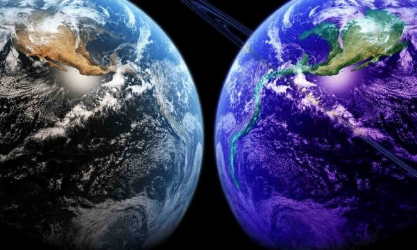

pic:What will happen in parallel universe?

The scores can be used to reduce or eliminate selection bias in observational studies by balancing covariates (the characteristics of participants) between treated and control groups. When the covariates are balanced, it become much easier to match participants with multiple characteristics. Propensity score allows one to design and analyze an observational (non-randomized) study so that it mimics some of the particular characteristics of a randomized controlled trial. Methods based on it can be used to reduce or eliminate the effects of confounding when using observational data to estimate treatment effects. To make such classification, generally logistic and probit regression is used.

## Propensity Score Matching

The concept of PSM was first introduced by Rosenbaum and Rubin (1983) in a paper entitled “The Central Role of the Propensity Score in Observational Studies for Casual Effects.” PSM is a statistical matching technique that attempts to estimate the effect of a treatment, policy, or other intervention by accounting for the covariates that predict receiving the treatment.

Propensity score matching creates sets of participants for treatment and control groups. A matched set consists of at least one participant in the treatment group and one in the control group with similar propensity scores. The goal is to approximate a random experiment, eliminating problems come with observational data analysis.

There are 4 different propensity score methods, matching on the propensity score, stratification on the propensity score, inverse probability of treatment weighting using the propensity score, and covariate adjustment using the propensity score.” [(Peter C. Austin. “An Introduction to Propensity Score Methods for Reducing the Effects of Confounding in Observational Studies”](https://www.tandfonline.com/doi/full/10.1080/00273171.2011.568786?src=recsys). Several studies have showed that propensity score matching eliminates a greater proportion of the systematic differences in baseline characteristics between treated and untreated subjects than does other methods do.

The PSM re-partitions the observational data so that treatment group and control group would have similar propensity score. Once we have matched sample, we can measure the treatment effect by directly comparing the treatment group and control group.

## Procedures and an Example

The basic steps to PSM are:

1.Collect data.

2.Estimate the propensity score and create a counter-factual group. We can estimate the propensity scores by many methods to approximate the true scores. Logistic and probit regression are widely used here. When you worry about the strong correlation between variables in the data, you had better use the probit regression since probit regression allows you to model among things that are correlated. Logistic regression assumes everything is independent in the model. Meanwhile, when the data shows normal distribution or the model focus on the binary choice, both regressions give us the same result. In this case, logistic regression is better since it runs faster.

3.Matching the real versus counter-factual samples using the estimated propensity scores.

4.Evaluate the covariates. Verify that covariates are balanced across treatment and comparison groups in the matched or weighted sample. The scores are good estimates for true propensity scores if the matching process successfully distributes covariates over the treatment and control groups.

Here we use PSM the comparison of samples in epidemiological studies.

```r
library(wakefield)
set.seed(1234)
df.patients <- r_data_frame(n = 250,
                            age(x = 30:78,
                                name = 'Age'),
                            sex(x = c("Male", "Female"),
                                prob = c(0.70, 0.30),
                                name = "Sex"))
df.patients$Sample <- as.factor('Patients')

summary(df.patients)
```

```
##       Age            Sex           Sample
##  Min.   :30.00   Male  :173   Patients:250
##  1st Qu.:42.00   Female: 77
##  Median :54.00
##  Mean   :53.71
##  3rd Qu.:66.00
##  Max.   :78.00
```

```r
set.seed(1234)
df.population <- r_data_frame(n = 1000,
                              age(x = 18:80,
                                  name = 'Age'),
                              sex(x = c("Male", "Female"),
                                  prob = c(0.50, 0.50),
                                  name = "Sex"))
df.population$Sample <- as.factor('Population')

summary(df.population)
```

```
##       Age            Sex             Sample
##  Min.   :18.00   Male  :485   Population:1000
##  1st Qu.:34.00   Female:515
##  Median :50.00
##  Mean   :49.46
##  3rd Qu.:65.00
##  Max.   :80.00
```

```r
mydata <- rbind(df.patients, df.population)
mydata$Group <- as.logical(mydata$Sample == 'Patients')
mydata$Distress <- ifelse(mydata$Sex == 'Male', age(nrow(mydata), x = 0:42, name = 'Distress'),
                                                age(nrow(mydata), x = 15:42, name = 'Distress'))
library(tableone)
table1 <- CreateTableOne(vars = c('Age', 'Sex', 'Distress'),
                         data = mydata,
                         factorVars = 'Sex',
                         strata = 'Sample')
table1 <- print(table1,
                printToggle = FALSE,
                noSpaces = TRUE)
knitr::kable(table1[,1:3],
      align = 'c',
      caption = 'Comparison of unmatched samples')
```

Comparison of unmatched samples

|  | Patients | Population | p |
| --- | --- | --- | --- |
| n | 250 | 1000 |  |
| Age (mean (SD)) | 53.71 (13.88) | 49.46 (18.33) | 0.001 |
| Sex = Female (%) | 77 (30.8) | 515 (51.5) | <0.001 |
| Distress (mean (SD)) | 22.86 (11.38) | 25.13 (11.11) | 0.004 |

Now that we have completed preparation and inspection of data, we are going to match the two samples using the matchit-function of the MatchIt package. The method command method=“nearest” specifies that the nearest neighbors method will be used.

After matching the samples, the size of the population sample was reduced to the size of the patient sample (n=250; see table 2).

```r
library(MatchIt)
set.seed(1234)
match.it <- matchit(Group ~ Age + Sex, data = mydata, method="nearest", ratio=1)
a <- summary(match.it)
knitr::kable(a$nn, digits = 2, align = 'c',
      caption = 'Sample sizes')
```

Sample sizes

|  | Control | Treated |
| --- | --- | --- |
| All | 1000 | 250 |
| Matched | 250 | 250 |
| Unmatched | 750 | 0 |
| Discarded | 0 | 0 |

The following output shows, that the distributions of the variables Age and Sex are nearly identical after matching.

```r
knitr::kable(a$sum.matched[c(1,2,4)], digits = 2, align = 'c',
      caption = 'Summary of balance for matched data')
```

Summary of balance for matched data

|  | Means Treated | Means Control | Mean Diff |
| --- | --- | --- | --- |
| distance | 0.23 | 0.23 | 0.00 |
| Age | 53.71 | 53.65 | 0.06 |
| SexMale | 0.69 | 0.69 | 0.00 |
| SexFemale | 0.31 | 0.31 | 0.00 |

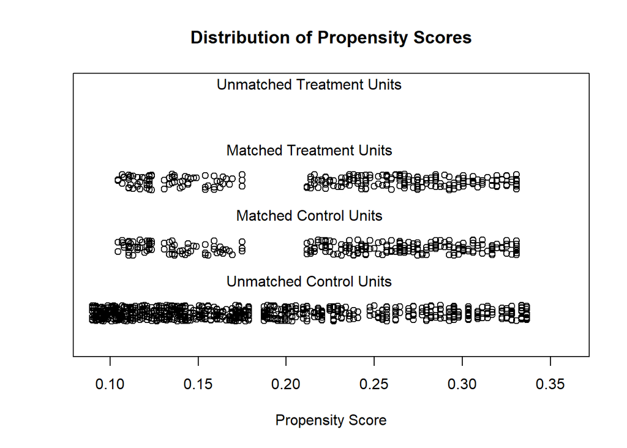

```r
plot(match.it, type = 'jitter', interactive = FALSE)
```

```r
df.match <- match.data(match.it)[1:ncol(mydata)]
rm(df.patients, df.population)
```

Eventually, we can check whether the differences in the level of distress between both samples are still significant.

```r
table4 <- CreateTableOne(vars = c('Age', 'Sex', 'Distress'),
                         data = df.match,
                         factorVars = 'Sex',
                         strata = 'Sample')
table4 <- print(table4,
                printToggle = FALSE,
                noSpaces = TRUE)
knitr::kable(table4[,1:3],
      align = 'c',
      caption = 'Table 4: Comparison of matched samples')
```

Table 4: Comparison of matched samples

|  | Patients | Population | p |
| --- | --- | --- | --- |
| n | 250 | 250 |  |
| Age (mean (SD)) | 53.71 (13.88) | 53.65 (13.86) | 0.961 |
| Sex = Female (%) | 77 (30.8) | 77 (30.8) | 1.000 |
| Distress (mean (SD)) | 22.86 (11.38) | 24.13 (11.88) | 0.222 |

With a p-value of 0.222, Student’s t-test does not indicate significant differences anymore. Thus, PSM helped to avoid an alpha mistake.

## Potential problems and weaknesses

The weaknesses of PSM comes from its attempts to approximate a completely randomized experiment. PSM is thus uniquely blind to the often large portion of imbalance that can be eliminated by approximating full blocking with other matching methods (Gary King, Richard Nielsen, 2018) . These problems make PSM often accomplish the increasing imbalance, inefficient, model dependence and bias. Perspectives below conclude their findings in that paper briefly.

1.Information ignored by propensity score.

Matching can be thought of as a technique for finding approximately ideal experimental data hidden with an observational data set. However, PSM approximates an experimental design with lower standards than necessary, thus failing to use all of the information available, and generating higher levels of imbalance, model dependence, and bias.

2.The propensity score paradox.

Weaknesses form PSM are not merely a matter of some avoidable inefficient. Instead, when data are well balanced either to begin with or after pruning some observations by matching, the fact that PSM is approximating the coin flips of a completely randomized experiment means that it will prune observations approximately randomly. The random pruning not only reduces the information in the data, it also increases the level of imbalance and thus increases model dependence and bias.

## Referrence

Jiaming Mao, *“Classification”*  
Norbert Köhler, *“How to use R for matching samples (propensity score)”*  
Statistics how to, *[“Propensity Score Matching: Definition & Overview”](https://www.statisticshowto.datasciencecentral.com/propensity-score-matching/)*  
Gary King, Richard Nielsen, *“Why Propensity Scores Should Not Be Used for Matching”*